# Risk Factor Analysis

## Outcome Variable

**Outcome Variable:** stunted

## Predictor Variables

**Intervention Variable:** fhtcm

**Adjustment Set:**

- arm
- W_mage
- W_fage
- meducyrs
- feducyrs
- W_mhtcm
- W_mwtkg
- W_mbmi
- single
- delta_W_mage
- delta_W_fage
- delta_meducyrs
- delta_feducyrs
- delta_W_mhtcm
- delta_W_mwtkg
- delta_W_mbmi
- delta_single

## Stratifying Variables

The analysis was stratified on these variable(s):

- agecat
- studyid
- country

## Data Summary

| agecat | studyid | country | fhtcm | stunted | n_cell | n |
| --- | --- | --- | --- | --- | --- | --- |
| Birth | ki1000304b-SAS-CompFeed | INDIA | >=167 cm | 0 | 253 | 746 |
| Birth | ki1000304b-SAS-CompFeed | INDIA | >=167 cm | 1 | 90 | 746 |
| Birth | ki1000304b-SAS-CompFeed | INDIA | <162 cm | 0 | 126 | 746 |
| Birth | ki1000304b-SAS-CompFeed | INDIA | <162 cm | 1 | 64 | 746 |
| Birth | ki1000304b-SAS-CompFeed | INDIA | [162-167) cm | 0 | 148 | 746 |
| Birth | ki1000304b-SAS-CompFeed | INDIA | [162-167) cm | 1 | 65 | 746 |
| Birth | ki1101329-Keneba | GAMBIA | >=167 cm | 0 | 735 | 1167 |
| Birth | ki1101329-Keneba | GAMBIA | >=167 cm | 1 | 37 | 1167 |
| Birth | ki1101329-Keneba | GAMBIA | <162 cm | 0 | 82 | 1167 |
| Birth | ki1101329-Keneba | GAMBIA | <162 cm | 1 | 5 | 1167 |
| Birth | ki1101329-Keneba | GAMBIA | [162-167) cm | 0 | 291 | 1167 |
| Birth | ki1101329-Keneba | GAMBIA | [162-167) cm | 1 | 17 | 1167 |
| Birth | ki1119695-PROBIT | BELARUS | >=167 cm | 0 | 11714 | 12533 |
| Birth | ki1119695-PROBIT | BELARUS | >=167 cm | 1 | 26 | 12533 |
| Birth | ki1119695-PROBIT | BELARUS | <162 cm | 0 | 168 | 12533 |
| Birth | ki1119695-PROBIT | BELARUS | <162 cm | 1 | 0 | 12533 |
| Birth | ki1119695-PROBIT | BELARUS | [162-167) cm | 0 | 622 | 12533 |
| Birth | ki1119695-PROBIT | BELARUS | [162-167) cm | 1 | 3 | 12533 |
| Birth | ki1135781-COHORTS | GUATEMALA | >=167 cm | 0 | 26 | 206 |
| Birth | ki1135781-COHORTS | GUATEMALA | >=167 cm | 1 | 3 | 206 |
| Birth | ki1135781-COHORTS | GUATEMALA | <162 cm | 0 | 111 | 206 |
| Birth | ki1135781-COHORTS | GUATEMALA | <162 cm | 1 | 10 | 206 |
| Birth | ki1135781-COHORTS | GUATEMALA | [162-167) cm | 0 | 54 | 206 |
| Birth | ki1135781-COHORTS | GUATEMALA | [162-167) cm | 1 | 2 | 206 |
| 6 months | ki1000304b-SAS-CompFeed | INDIA | >=167 cm | 0 | 281 | 807 |
| 6 months | ki1000304b-SAS-CompFeed | INDIA | >=167 cm | 1 | 88 | 807 |
| 6 months | ki1000304b-SAS-CompFeed | INDIA | <162 cm | 0 | 129 | 807 |
| 6 months | ki1000304b-SAS-CompFeed | INDIA | <162 cm | 1 | 65 | 807 |
| 6 months | ki1000304b-SAS-CompFeed | INDIA | [162-167) cm | 0 | 168 | 807 |
| 6 months | ki1000304b-SAS-CompFeed | INDIA | [162-167) cm | 1 | 76 | 807 |
| 6 months | ki1000304b-SAS-FoodSuppl | INDIA | >=167 cm | 0 | 64 | 372 |
| 6 months | ki1000304b-SAS-FoodSuppl | INDIA | >=167 cm | 1 | 38 | 372 |
| 6 months | ki1000304b-SAS-FoodSuppl | INDIA | <162 cm | 0 | 72 | 372 |
| 6 months | ki1000304b-SAS-FoodSuppl | INDIA | <162 cm | 1 | 76 | 372 |
| 6 months | ki1000304b-SAS-FoodSuppl | INDIA | [162-167) cm | 0 | 77 | 372 |
| 6 months | ki1000304b-SAS-FoodSuppl | INDIA | [162-167) cm | 1 | 45 | 372 |
| 6 months | ki1101329-Keneba | GAMBIA | >=167 cm | 0 | 849 | 1511 |
| 6 months | ki1101329-Keneba | GAMBIA | >=167 cm | 1 | 130 | 1511 |
| 6 months | ki1101329-Keneba | GAMBIA | <162 cm | 0 | 98 | 1511 |
| 6 months | ki1101329-Keneba | GAMBIA | <162 cm | 1 | 15 | 1511 |
| 6 months | ki1101329-Keneba | GAMBIA | [162-167) cm | 0 | 355 | 1511 |
| 6 months | ki1101329-Keneba | GAMBIA | [162-167) cm | 1 | 64 | 1511 |
| 6 months | ki1119695-PROBIT | BELARUS | >=167 cm | 0 | 10535 | 11895 |
| 6 months | ki1119695-PROBIT | BELARUS | >=167 cm | 1 | 611 | 11895 |
| 6 months | ki1119695-PROBIT | BELARUS | <162 cm | 0 | 131 | 11895 |
| 6 months | ki1119695-PROBIT | BELARUS | <162 cm | 1 | 25 | 11895 |
| 6 months | ki1119695-PROBIT | BELARUS | [162-167) cm | 0 | 529 | 11895 |
| 6 months | ki1119695-PROBIT | BELARUS | [162-167) cm | 1 | 64 | 11895 |
| 6 months | ki1135781-COHORTS | GUATEMALA | >=167 cm | 0 | 31 | 336 |
| 6 months | ki1135781-COHORTS | GUATEMALA | >=167 cm | 1 | 14 | 336 |
| 6 months | ki1135781-COHORTS | GUATEMALA | <162 cm | 0 | 88 | 336 |
| 6 months | ki1135781-COHORTS | GUATEMALA | <162 cm | 1 | 109 | 336 |
| 6 months | ki1135781-COHORTS | GUATEMALA | [162-167) cm | 0 | 61 | 336 |
| 6 months | ki1135781-COHORTS | GUATEMALA | [162-167) cm | 1 | 33 | 336 |
| 24 months | ki1101329-Keneba | GAMBIA | >=167 cm | 0 | 565 | 1297 |
| 24 months | ki1101329-Keneba | GAMBIA | >=167 cm | 1 | 256 | 1297 |
| 24 months | ki1101329-Keneba | GAMBIA | <162 cm | 0 | 63 | 1297 |
| 24 months | ki1101329-Keneba | GAMBIA | <162 cm | 1 | 34 | 1297 |
| 24 months | ki1101329-Keneba | GAMBIA | [162-167) cm | 0 | 216 | 1297 |
| 24 months | ki1101329-Keneba | GAMBIA | [162-167) cm | 1 | 163 | 1297 |
| 24 months | ki1119695-PROBIT | BELARUS | >=167 cm | 0 | 3161 | 3670 |
| 24 months | ki1119695-PROBIT | BELARUS | >=167 cm | 1 | 284 | 3670 |
| 24 months | ki1119695-PROBIT | BELARUS | <162 cm | 0 | 42 | 3670 |
| 24 months | ki1119695-PROBIT | BELARUS | <162 cm | 1 | 11 | 3670 |
| 24 months | ki1119695-PROBIT | BELARUS | [162-167) cm | 0 | 149 | 3670 |
| 24 months | ki1119695-PROBIT | BELARUS | [162-167) cm | 1 | 23 | 3670 |
| 24 months | ki1135781-COHORTS | GUATEMALA | >=167 cm | 0 | 24 | 526 |
| 24 months | ki1135781-COHORTS | GUATEMALA | >=167 cm | 1 | 46 | 526 |
| 24 months | ki1135781-COHORTS | GUATEMALA | <162 cm | 0 | 40 | 526 |
| 24 months | ki1135781-COHORTS | GUATEMALA | <162 cm | 1 | 267 | 526 |
| 24 months | ki1135781-COHORTS | GUATEMALA | [162-167) cm | 0 | 36 | 526 |
| 24 months | ki1135781-COHORTS | GUATEMALA | [162-167) cm | 1 | 113 | 526 |

The following strata were considered:

- agecat: 24 months, studyid: ki1101329-Keneba, country: GAMBIA
- agecat: 24 months, studyid: ki1119695-PROBIT, country: BELARUS
- agecat: 24 months, studyid: ki1135781-COHORTS, country: GUATEMALA
- agecat: 6 months, studyid: ki1000304b-SAS-CompFeed, country: INDIA
- agecat: 6 months, studyid: ki1000304b-SAS-FoodSuppl, country: INDIA
- agecat: 6 months, studyid: ki1101329-Keneba, country: GAMBIA
- agecat: 6 months, studyid: ki1119695-PROBIT, country: BELARUS
- agecat: 6 months, studyid: ki1135781-COHORTS, country: GUATEMALA
- agecat: Birth, studyid: ki1000304b-SAS-CompFeed, country: INDIA
- agecat: Birth, studyid: ki1101329-Keneba, country: GAMBIA
- agecat: Birth, studyid: ki1119695-PROBIT, country: BELARUS
- agecat: Birth, studyid: ki1135781-COHORTS, country: GUATEMALA

### Dropped Strata

Some strata were dropped due to rare outcomes:

- agecat: Birth, studyid: ki1119695-PROBIT, country: BELARUS
- agecat: Birth, studyid: ki1135781-COHORTS, country: GUATEMALA

## Methods Detail

We’re interested in the causal parameters $E[Y_a]$ for all values of $a \in \mathcal{A}$. These parameters represent the mean outcome if, possibly contrary to fact, we intervened to set all units to have $A=a$. Under the randomization and positivity assumptions, these are identified by the statistical parameters $\psi_a=E_W[E_{Y|A,W}(Y|A=a,W)]$. In addition, we’re interested in the mean of $Y$, $E[Y]$ under no intervention (the observed mean). We will estimate these parameters by using SuperLearner to fit the relevant likelihood factors – $E_{Y|A,W}(Y|A=a,W)$ and $p(A=a|W)$, and then updating our likelihood fit using a joint TMLE.

For unadjusted analyses ($W=\{\}$), initial likelihoods were estimated using Lrnr_glm to estimate the simple $E(Y|A)$ and Lrnr_mean to estimate $p(A)$. For adjusted analyses, a small library containing Lrnr_glmnet, Lrnr_xgboost, and Lrnr_mean was used.

Having estimated these parameters, we will then use the delta method to estimate relative risks and attributable risks relative to a prespecified baseline level of $A$.

# Results Detail

## Results Plots

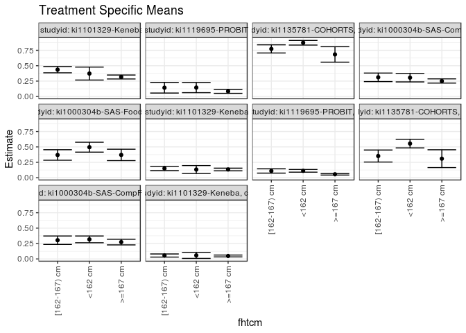

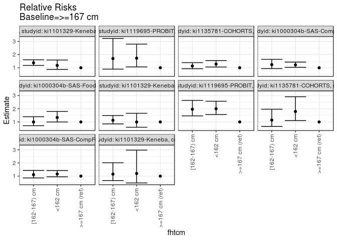

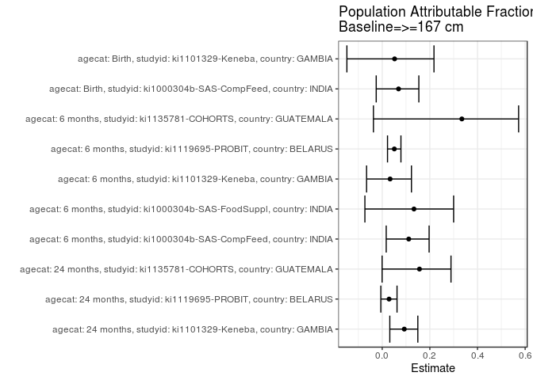

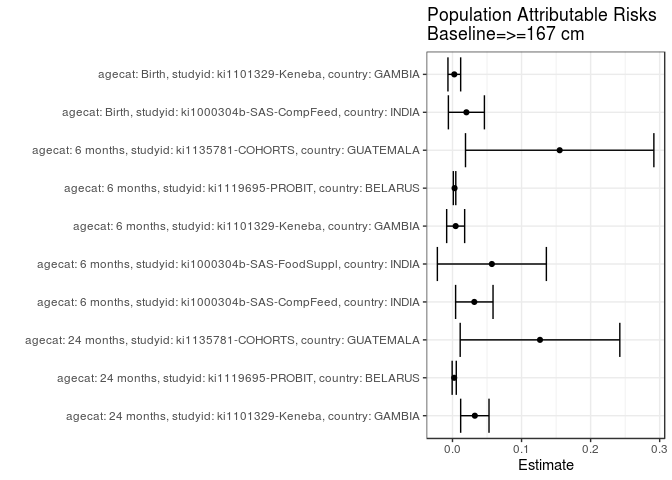

## Results Table

### Parameter: TSM

| agecat | studyid | country | intervention_level | baseline_level | estimate | ci_lower | ci_upper |
| --- | --- | --- | --- | --- | --- | --- | --- |
| Birth | ki1000304b-SAS-CompFeed | INDIA | >=167 cm | NA | 0.2734250 | 0.2277502 | 0.3190999 |
| Birth | ki1000304b-SAS-CompFeed | INDIA | <162 cm | NA | 0.3175758 | 0.2628426 | 0.3723089 |
| Birth | ki1000304b-SAS-CompFeed | INDIA | [162-167) cm | NA | 0.3039056 | 0.2354628 | 0.3723485 |
| Birth | ki1101329-Keneba | GAMBIA | >=167 cm | NA | 0.0479275 | 0.0328526 | 0.0630023 |
| Birth | ki1101329-Keneba | GAMBIA | <162 cm | NA | 0.0574713 | 0.0085444 | 0.1063981 |
| Birth | ki1101329-Keneba | GAMBIA | [162-167) cm | NA | 0.0551948 | 0.0296808 | 0.0807088 |
| 6 months | ki1000304b-SAS-CompFeed | INDIA | >=167 cm | NA | 0.2521530 | 0.2179136 | 0.2863924 |
| 6 months | ki1000304b-SAS-CompFeed | INDIA | <162 cm | NA | 0.3064188 | 0.2371949 | 0.3756428 |
| 6 months | ki1000304b-SAS-CompFeed | INDIA | [162-167) cm | NA | 0.3116115 | 0.2423894 | 0.3808335 |
| 6 months | ki1000304b-SAS-FoodSuppl | INDIA | >=167 cm | NA | 0.3704068 | 0.2780769 | 0.4627366 |
| 6 months | ki1000304b-SAS-FoodSuppl | INDIA | <162 cm | NA | 0.4957813 | 0.4154078 | 0.5761547 |
| 6 months | ki1000304b-SAS-FoodSuppl | INDIA | [162-167) cm | NA | 0.3692195 | 0.2841003 | 0.4543386 |
| 6 months | ki1101329-Keneba | GAMBIA | >=167 cm | NA | 0.1337275 | 0.1124611 | 0.1549939 |
| 6 months | ki1101329-Keneba | GAMBIA | <162 cm | NA | 0.1329844 | 0.0685567 | 0.1974122 |
| 6 months | ki1101329-Keneba | GAMBIA | [162-167) cm | NA | 0.1503012 | 0.1159064 | 0.1846961 |
| 6 months | ki1119695-PROBIT | BELARUS | >=167 cm | NA | 0.0558540 | 0.0437788 | 0.0679292 |
| 6 months | ki1119695-PROBIT | BELARUS | <162 cm | NA | 0.1119433 | 0.0903239 | 0.1335628 |
| 6 months | ki1119695-PROBIT | BELARUS | [162-167) cm | NA | 0.1096075 | 0.0747205 | 0.1444945 |
| 6 months | ki1135781-COHORTS | GUATEMALA | >=167 cm | NA | 0.3090688 | 0.1642945 | 0.4538431 |
| 6 months | ki1135781-COHORTS | GUATEMALA | <162 cm | NA | 0.5542306 | 0.4843251 | 0.6241361 |
| 6 months | ki1135781-COHORTS | GUATEMALA | [162-167) cm | NA | 0.3522287 | 0.2544046 | 0.4500528 |
| 24 months | ki1101329-Keneba | GAMBIA | >=167 cm | NA | 0.3169118 | 0.2847749 | 0.3490486 |
| 24 months | ki1101329-Keneba | GAMBIA | <162 cm | NA | 0.3726916 | 0.2676415 | 0.4777417 |
| 24 months | ki1101329-Keneba | GAMBIA | [162-167) cm | NA | 0.4360010 | 0.3848638 | 0.4871382 |
| 24 months | ki1119695-PROBIT | BELARUS | >=167 cm | NA | 0.0841512 | 0.0514795 | 0.1168229 |
| 24 months | ki1119695-PROBIT | BELARUS | <162 cm | NA | 0.1451524 | 0.0621572 | 0.2281476 |
| 24 months | ki1119695-PROBIT | BELARUS | [162-167) cm | NA | 0.1427759 | 0.0560815 | 0.2294704 |
| 24 months | ki1135781-COHORTS | GUATEMALA | >=167 cm | NA | 0.6831685 | 0.5577558 | 0.8085812 |
| 24 months | ki1135781-COHORTS | GUATEMALA | <162 cm | NA | 0.8727662 | 0.8352476 | 0.9102848 |
| 24 months | ki1135781-COHORTS | GUATEMALA | [162-167) cm | NA | 0.7729278 | 0.7066089 | 0.8392467 |

### Parameter: E(Y)

| agecat | studyid | country | intervention_level | baseline_level | estimate | ci_lower | ci_upper |
| --- | --- | --- | --- | --- | --- | --- | --- |
| Birth | ki1000304b-SAS-CompFeed | INDIA | NA | NA | 0.2935657 | 0.2562276 | 0.3309038 |
| Birth | ki1101329-Keneba | GAMBIA | NA | NA | 0.0505570 | 0.0379815 | 0.0631324 |
| 6 months | ki1000304b-SAS-CompFeed | INDIA | NA | NA | 0.2837670 | 0.2471555 | 0.3203786 |
| 6 months | ki1000304b-SAS-FoodSuppl | INDIA | NA | NA | 0.4274194 | 0.3770801 | 0.4777586 |
| 6 months | ki1101329-Keneba | GAMBIA | NA | NA | 0.1383190 | 0.1209060 | 0.1557320 |
| 6 months | ki1119695-PROBIT | BELARUS | NA | NA | 0.0588483 | 0.0462144 | 0.0714821 |
| 6 months | ki1135781-COHORTS | GUATEMALA | NA | NA | 0.4642857 | 0.4108803 | 0.5176911 |
| 24 months | ki1101329-Keneba | GAMBIA | NA | NA | 0.3492675 | 0.3233122 | 0.3752228 |
| 24 months | ki1119695-PROBIT | BELARUS | NA | NA | 0.0866485 | 0.0534930 | 0.1198040 |
| 24 months | ki1135781-COHORTS | GUATEMALA | NA | NA | 0.8098859 | 0.7763209 | 0.8434510 |

### Parameter: RR

| agecat | studyid | country | intervention_level | baseline_level | estimate | ci_lower | ci_upper |
| --- | --- | --- | --- | --- | --- | --- | --- |
| Birth | ki1000304b-SAS-CompFeed | INDIA | >=167 cm | >=167 cm | 1.0000000 | 1.0000000 | 1.000000 |
| Birth | ki1000304b-SAS-CompFeed | INDIA | <162 cm | >=167 cm | 1.1614728 | 0.9485658 | 1.422167 |
| Birth | ki1000304b-SAS-CompFeed | INDIA | [162-167) cm | >=167 cm | 1.1114769 | 0.8626373 | 1.432098 |
| Birth | ki1101329-Keneba | GAMBIA | >=167 cm | >=167 cm | 1.0000000 | 1.0000000 | 1.000000 |
| Birth | ki1101329-Keneba | GAMBIA | <162 cm | >=167 cm | 1.1991302 | 0.4838515 | 2.971807 |
| Birth | ki1101329-Keneba | GAMBIA | [162-167) cm | >=167 cm | 1.1516321 | 0.6584043 | 2.014350 |
| 6 months | ki1000304b-SAS-CompFeed | INDIA | >=167 cm | >=167 cm | 1.0000000 | 1.0000000 | 1.000000 |
| 6 months | ki1000304b-SAS-CompFeed | INDIA | <162 cm | >=167 cm | 1.2152099 | 1.0339183 | 1.428290 |
| 6 months | ki1000304b-SAS-CompFeed | INDIA | [162-167) cm | >=167 cm | 1.2358030 | 0.9313452 | 1.639788 |
| 6 months | ki1000304b-SAS-FoodSuppl | INDIA | >=167 cm | >=167 cm | 1.0000000 | 1.0000000 | 1.000000 |
| 6 months | ki1000304b-SAS-FoodSuppl | INDIA | <162 cm | >=167 cm | 1.3384779 | 0.9966070 | 1.797622 |
| 6 months | ki1000304b-SAS-FoodSuppl | INDIA | [162-167) cm | >=167 cm | 0.9967947 | 0.7122673 | 1.394982 |
| 6 months | ki1101329-Keneba | GAMBIA | >=167 cm | >=167 cm | 1.0000000 | 1.0000000 | 1.000000 |
| 6 months | ki1101329-Keneba | GAMBIA | <162 cm | >=167 cm | 0.9944434 | 0.5972013 | 1.655920 |
| 6 months | ki1101329-Keneba | GAMBIA | [162-167) cm | >=167 cm | 1.1239363 | 0.8508156 | 1.484732 |
| 6 months | ki1119695-PROBIT | BELARUS | >=167 cm | >=167 cm | 1.0000000 | 1.0000000 | 1.000000 |
| 6 months | ki1119695-PROBIT | BELARUS | <162 cm | >=167 cm | 2.0042126 | 1.5630845 | 2.569834 |
| 6 months | ki1119695-PROBIT | BELARUS | [162-167) cm | >=167 cm | 1.9623926 | 1.4599302 | 2.637787 |
| 6 months | ki1135781-COHORTS | GUATEMALA | >=167 cm | >=167 cm | 1.0000000 | 1.0000000 | 1.000000 |
| 6 months | ki1135781-COHORTS | GUATEMALA | <162 cm | >=167 cm | 1.7932273 | 1.1039857 | 2.912777 |
| 6 months | ki1135781-COHORTS | GUATEMALA | [162-167) cm | >=167 cm | 1.1396450 | 0.6607966 | 1.965492 |
| 24 months | ki1101329-Keneba | GAMBIA | >=167 cm | >=167 cm | 1.0000000 | 1.0000000 | 1.000000 |
| 24 months | ki1101329-Keneba | GAMBIA | <162 cm | >=167 cm | 1.1760106 | 0.8718392 | 1.586303 |
| 24 months | ki1101329-Keneba | GAMBIA | [162-167) cm | >=167 cm | 1.3757804 | 1.1797438 | 1.604392 |
| 24 months | ki1119695-PROBIT | BELARUS | >=167 cm | >=167 cm | 1.0000000 | 1.0000000 | 1.000000 |
| 24 months | ki1119695-PROBIT | BELARUS | <162 cm | >=167 cm | 1.7248999 | 1.0654548 | 2.792497 |
| 24 months | ki1119695-PROBIT | BELARUS | [162-167) cm | >=167 cm | 1.6966597 | 0.8933712 | 3.222237 |
| 24 months | ki1135781-COHORTS | GUATEMALA | >=167 cm | >=167 cm | 1.0000000 | 1.0000000 | 1.000000 |
| 24 months | ki1135781-COHORTS | GUATEMALA | <162 cm | >=167 cm | 1.2775271 | 1.0584097 | 1.542007 |
| 24 months | ki1135781-COHORTS | GUATEMALA | [162-167) cm | >=167 cm | 1.1313868 | 0.9246185 | 1.384394 |

### Parameter: PAR

| agecat | studyid | country | intervention_level | baseline_level | estimate | ci_lower | ci_upper |
| --- | --- | --- | --- | --- | --- | --- | --- |
| Birth | ki1000304b-SAS-CompFeed | INDIA | >=167 cm | NA | 0.0201406 | -0.0059426 | 0.0462239 |
| Birth | ki1101329-Keneba | GAMBIA | >=167 cm | NA | 0.0026295 | -0.0065753 | 0.0118343 |
| 6 months | ki1000304b-SAS-CompFeed | INDIA | >=167 cm | NA | 0.0316140 | 0.0045181 | 0.0587100 |
| 6 months | ki1000304b-SAS-FoodSuppl | INDIA | >=167 cm | NA | 0.0570126 | -0.0219074 | 0.1359326 |
| 6 months | ki1101329-Keneba | GAMBIA | >=167 cm | NA | 0.0045915 | -0.0084273 | 0.0176102 |
| 6 months | ki1119695-PROBIT | BELARUS | >=167 cm | NA | 0.0029942 | 0.0012060 | 0.0047825 |
| 6 months | ki1135781-COHORTS | GUATEMALA | >=167 cm | NA | 0.1552169 | 0.0188400 | 0.2915938 |
| 24 months | ki1101329-Keneba | GAMBIA | >=167 cm | NA | 0.0323558 | 0.0118359 | 0.0528756 |
| 24 months | ki1119695-PROBIT | BELARUS | >=167 cm | NA | 0.0024973 | -0.0004928 | 0.0054874 |
| 24 months | ki1135781-COHORTS | GUATEMALA | >=167 cm | NA | 0.1267175 | 0.0111432 | 0.2422918 |

### Parameter: PAF

| agecat | studyid | country | intervention_level | baseline_level | estimate | ci_lower | ci_upper |
| --- | --- | --- | --- | --- | --- | --- | --- |
| Birth | ki1000304b-SAS-CompFeed | INDIA | >=167 cm | NA | 0.0686069 | -0.0251466 | 0.1537863 |
| Birth | ki1101329-Keneba | GAMBIA | >=167 cm | NA | 0.0520111 | -0.1482148 | 0.2173215 |
| 6 months | ki1000304b-SAS-CompFeed | INDIA | >=167 cm | NA | 0.1114083 | 0.0168404 | 0.1968800 |
| 6 months | ki1000304b-SAS-FoodSuppl | INDIA | >=167 cm | NA | 0.1333880 | -0.0726455 | 0.2998466 |
| 6 months | ki1101329-Keneba | GAMBIA | >=167 cm | NA | 0.0331948 | -0.0655547 | 0.1227928 |
| 6 months | ki1119695-PROBIT | BELARUS | >=167 cm | NA | 0.0508807 | 0.0222997 | 0.0786261 |
| 6 months | ki1135781-COHORTS | GUATEMALA | >=167 cm | NA | 0.3343133 | -0.0368056 | 0.5725923 |
| 24 months | ki1101329-Keneba | GAMBIA | >=167 cm | NA | 0.0926389 | 0.0319409 | 0.1495311 |
| 24 months | ki1119695-PROBIT | BELARUS | >=167 cm | NA | 0.0288212 | -0.0057785 | 0.0622306 |
| 24 months | ki1135781-COHORTS | GUATEMALA | >=167 cm | NA | 0.1564633 | -0.0004238 | 0.2887474 |